# Practical Machine Learning: Prediction Assignment

Kirsten

24/10/2022

```r
knitr::opts_chunk$set(cache = TRUE)
```

#Assignment Outline

The assessment aims to model the quality of an exercise based on a number of metrics collected from wearably devices.

Six young health participants were asked to perform one set of 10 repetitions of the Unilateral Dumbbell Biceps Curl in five different fashions: exactly according to the specification (Class A), throwing the elbows to the front (Class B), lifting the dumbbell only halfway (Class C), lowering the dumbbell only halfway (Class D) and throwing the hips to the front (Class E) (reference: http:/groupware.les.inf.puc-rio.br/har#ixzz4TjsXrJdH )

```r
## Load required packages
library(caret)
library(randomForest)
```

```r
library(rpart.plot)
library(gbm)
library(stats)
library(Metrics)
setwd("C:/Users/kirstend/Desktop/RLearing")
```

```r
## set seed for reproducibility:
set.seed(504)

## Load test and training data

training_data <- read.csv("pml-training.csv")
testing_data <- read.csv("pml-testing.csv")
inTrain <- createDataPartition(training_data$classe, p=0.6, list=FALSE)
myTraining <- training_data[inTrain, ]
myTesting <- training_data[-inTrain, ]
```

## Cleaning Data

Having set the seed to insure reroducability, and loading the data, it is clear to see there is some cleaning required. The raw data has 160 variables, of which only some are impacting the classification of the activity. Therefore any columns with a negligible variance, as well as columns with no bearing on the activity were removed.

```r
# remove variables with nearly zero variance
nzv <- nearZeroVar(myTraining)
myTraining <- myTraining[, -nzv]
myTesting <- myTesting[, -nzv]

# remove variables that are almostly NA
mostlyNA <- sapply(myTraining, function(x) mean(is.na(x))) > 0.95
myTraining1 <- myTraining[, mostlyNA==F]
myTesting <- myTesting[, mostlyNA==F]

# remove identification only variables (columns 1 to 5)
myTraining <- myTraining1[, -(1:5)]
myTesting  <- myTesting[, -(1:5)]

myTraining$classe <- factor(myTraining$classe)
myTesting$classe <- factor(myTesting$classe)
```

## Modeling the data:

The training data is split into both a training and a test set, to insure cross-validation is applied. The split is on a 60/40 percentage. Thereafter the factor variables are defined and a number of models are trained on the data. The models tested are as follows:

- Random Forest
- Decision Tree
- Generalised Boosted Analysis
- Linear Discriminate Analysis

THe output from the Random forest model can be seen below, with the model returning good accuracy:

```r
# Random Forest
# randF <- train(classe~.,data= myTraining, method = "rf") # this took too long, so used:
randF <- randomForest(classe ~., data = myTraining)
randF
```

```
##
## Call:
##  randomForest(formula = classe ~ ., data = myTraining)
##                Type of random forest: classification
##                      Number of trees: 500
## No. of variables tried at each split: 7
##
##         OOB estimate of  error rate: 0.42%
## Confusion matrix:
##      A    B    C    D    E  class.error
## A 3345    2    0    0    1 0.0008960573
## B    5 2270    4    0    0 0.0039491005
## C    0    6 2045    3    0 0.0043816943
## D    0    0   20 1908    2 0.0113989637
## E    0    0    0    6 2159 0.0027713626
```

The Decision tree assessment, however, was not as successful, with a much lower accuracy, and a null classification of the activity “classe D”:

```r
# Decision Tree
decTree <- train(classe~., data = myTraining, method = "rpart")
decTree
```

```
## CART
##
## 11776 samples
##    53 predictor
##     5 classes: 'A', 'B', 'C', 'D', 'E'
##
## No pre-processing
## Resampling: Bootstrapped (25 reps)
## Summary of sample sizes: 11776, 11776, 11776, 11776, 11776, 11776, ...
## Resampling results across tuning parameters:
##
##   cp          Accuracy   Kappa
##   0.04170622  0.5162324  0.37251870
##   0.05936561  0.4026405  0.18651983
##   0.11841481  0.3304033  0.07091767
##
## Accuracy was used to select the optimal model using the largest value.
## The final value used for the model was cp = 0.04170622.
```

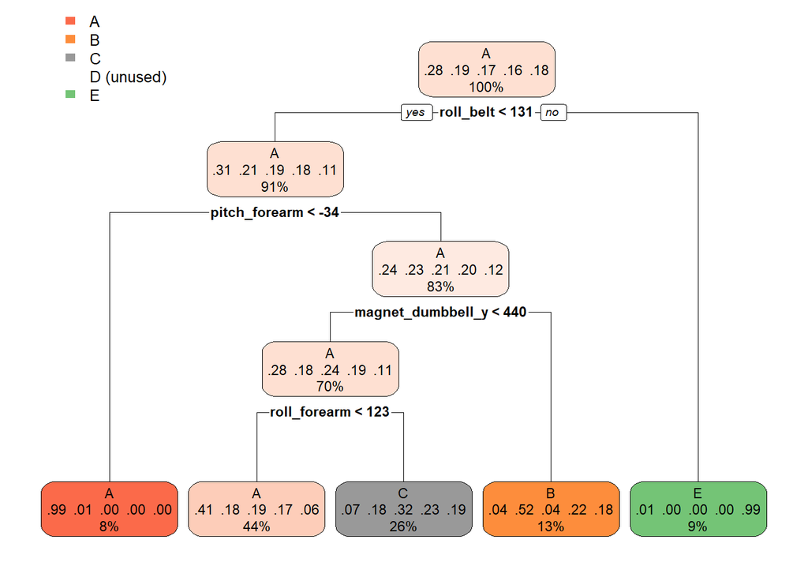

```r
rpart.plot(decTree$finalModel)
```

```r
# Generalized Boosted Model (GBM)
GBM_mod <- gbm(classe~., data = myTraining,  cv.folds = 10, verbose = FALSE)
```

```
## Distribution not specified, assuming multinomial ...
```

```
## Warning: Setting `distribution = "multinomial"` is ill-advised as it is
## currently broken. It exists only for backwards compatibility. Use at your own
## risk.
```

```r
GBM_mod
```

```
## gbm(formula = classe ~ ., data = myTraining, cv.folds = 10, verbose = FALSE)
## A gradient boosted model with multinomial loss function.
## 100 iterations were performed.
## The best cross-validation iteration was 100.
## There were 53 predictors of which 45 had non-zero influence.
```

```r
perf_gbm1 = gbm.perf(GBM_mod, method = "cv")
```

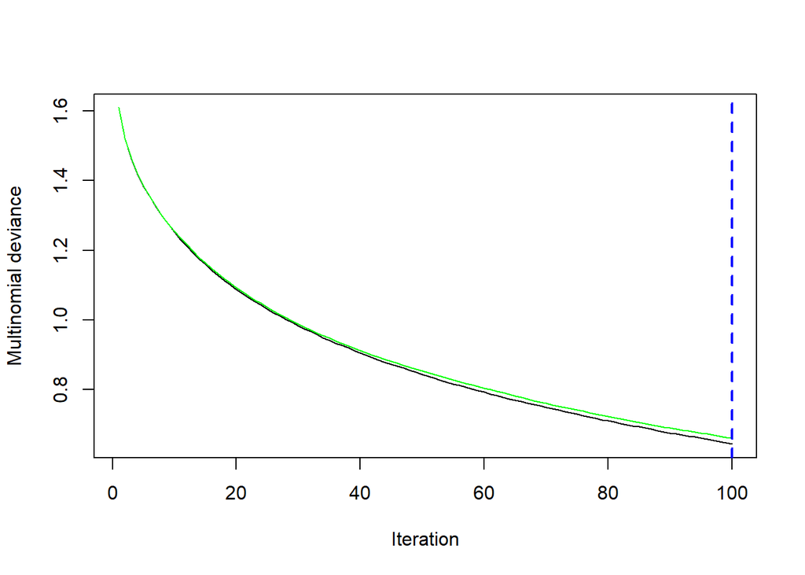

As an addition, a Linear discriminate analysis run, returning a lower accuracy than the random forest:

```r
# Linear Discriminate Analysis
LDA_mod <- train(classe~., myTraining,method = "lda")
LDA_mod
```

```
## Linear Discriminant Analysis
##
## 11776 samples
##    53 predictor
##     5 classes: 'A', 'B', 'C', 'D', 'E'
##
## No pre-processing
## Resampling: Bootstrapped (25 reps)
## Summary of sample sizes: 11776, 11776, 11776, 11776, 11776, 11776, ...
## Resampling results:
##
##   Accuracy   Kappa
##   0.7097443  0.6329847
```

## Testing on partitioned Data:

```r
### Predictions:

# Prediction using Random forest
predict_rf <- predict(randF, myTesting, type="class")
confusionMatrix(myTesting$classe, predict_rf)
```

```
## Confusion Matrix and Statistics
##
##           Reference
## Prediction    A    B    C    D    E
##          A 2232    0    0    0    0
##          B    2 1516    0    0    0
##          C    0    2 1366    0    0
##          D    0    0    7 1277    2
##          E    0    0    0    1 1441
##
## Overall Statistics
##
##                Accuracy : 0.9982
##                  95% CI : (0.997, 0.999)
##     No Information Rate : 0.2847
##     P-Value [Acc > NIR] : < 2.2e-16
##
##                   Kappa : 0.9977
##
##  Mcnemar's Test P-Value : NA
##
## Statistics by Class:
##
##                      Class: A Class: B Class: C Class: D Class: E
## Sensitivity            0.9991   0.9987   0.9949   0.9992   0.9986
## Specificity            1.0000   0.9997   0.9997   0.9986   0.9998
## Pos Pred Value         1.0000   0.9987   0.9985   0.9930   0.9993
## Neg Pred Value         0.9996   0.9997   0.9989   0.9998   0.9997
## Prevalence             0.2847   0.1935   0.1750   0.1629   0.1839
## Detection Rate         0.2845   0.1932   0.1741   0.1628   0.1837
## Detection Prevalence   0.2845   0.1935   0.1744   0.1639   0.1838
## Balanced Accuracy      0.9996   0.9992   0.9973   0.9989   0.9992
```

```r
# Prediction using Decision tree
predict_dt <- predict(decTree, myTesting)
confusionMatrix(myTesting$classe, predict_dt)
```

```
## Confusion Matrix and Statistics
##
##           Reference
## Prediction    A    B    C    D    E
##          A 2023   27  178    0    4
##          B  638  500  380    0    0
##          C  594   47  727    0    0
##          D  574  227  485    0    0
##          E  226  205  388    0  623
##
## Overall Statistics
##
##                Accuracy : 0.4936
##                  95% CI : (0.4825, 0.5048)
##     No Information Rate : 0.5168
##     P-Value [Acc > NIR] : 1
##
##                   Kappa : 0.3385
##
##  Mcnemar's Test P-Value : NA
##
## Statistics by Class:
##
##                      Class: A Class: B Class: C Class: D Class: E
## Sensitivity            0.4989  0.49702  0.33689       NA  0.99362
## Specificity            0.9449  0.85117  0.88731   0.8361  0.88655
## Pos Pred Value         0.9064  0.32938  0.53143       NA  0.43204
## Neg Pred Value         0.6380  0.92004  0.77910       NA  0.99938
## Prevalence             0.5168  0.12822  0.27504   0.0000  0.07991
## Detection Rate         0.2578  0.06373  0.09266   0.0000  0.07940
## Detection Prevalence   0.2845  0.19347  0.17436   0.1639  0.18379
## Balanced Accuracy      0.7219  0.67409  0.61210       NA  0.94008
```

```r
# Prediction using GBM
#predict_GBM <- stats::predict(GBM_mod, myTesting, n.trees = perf_gbm1)
#rmse_GBM <- rmse(predict_GBM, myTesting$classe)
#print(rmse_GBM)

# Prediction using LDA
predict_LDA <- predict(LDA_mod, myTesting)
confusionMatrix(myTesting$classe, predict_LDA)
```

```
## Confusion Matrix and Statistics
##
##           Reference
## Prediction    A    B    C    D    E
##          A 1819   75  158  167   13
##          B  211 1011  175   55   66
##          C  126  142  881  181   38
##          D   69   50  166  963   38
##          E   67  206  141  137  891
##
## Overall Statistics
##
##                Accuracy : 0.7093
##                  95% CI : (0.6991, 0.7193)
##     No Information Rate : 0.2921
##     P-Value [Acc > NIR] : < 2.2e-16
##
##                   Kappa : 0.6323
##
##  Mcnemar's Test P-Value : < 2.2e-16
##
## Statistics by Class:
##
##                      Class: A Class: B Class: C Class: D Class: E
## Sensitivity            0.7936   0.6813   0.5792   0.6407   0.8518
## Specificity            0.9256   0.9203   0.9230   0.9491   0.9190
## Pos Pred Value         0.8150   0.6660   0.6440   0.7488   0.6179
## Neg Pred Value         0.9157   0.9253   0.9012   0.9177   0.9758
## Prevalence             0.2921   0.1891   0.1939   0.1916   0.1333
## Detection Rate         0.2318   0.1289   0.1123   0.1227   0.1136
## Detection Prevalence   0.2845   0.1935   0.1744   0.1639   0.1838
## Balanced Accuracy      0.8596   0.8008   0.7511   0.7949   0.8854
```

```r
# Grouping model for improved performance - this did not improve the performace at all, thus was removed.
#predcombo <- data.frame(predict_rf,predict_GBM,classe = myTesting$classe)
#combModFit <- train(classe ~., method = "gam", data = predcombo)
#combPredict <- predict(combModFit, predcombo)
```

## Conclusion and final testing:

Therefore it was decided to conduct the final prediction on the test data using the random forest model (accuracy = 0.9982157):

```r
finalmod <- predict(randF,testing_data)
```

The output returned a 100% correct, having submitted te values in the automated quiz check.

## References:

The work of the following two authors was referenced during the assignment: - https://github.com/vevagm/Practical-Machine-Learning-Course-Project/commit/963ea9a91dd343bd560b8689cdbf8d80de04cbad#diff-827a6befc06430da5ec372b3594cce04affcb80172b848c4287604537f924417 - https://myhero105.github.io/Coursera-Practical-Machine-Learning-Course-Project/

## Appendix:

PLots on model comparions below:

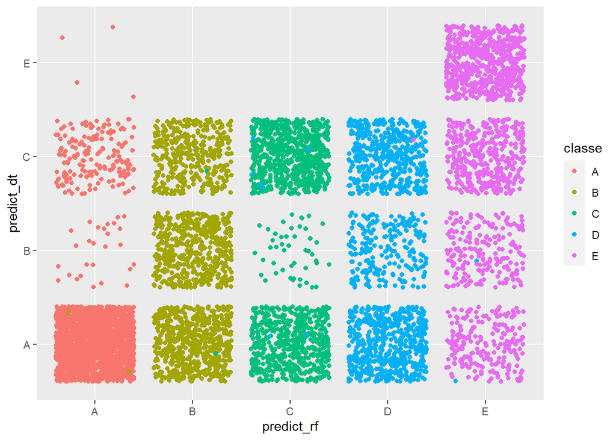

```r
qplot(predict_rf,predict_dt,colour = classe, data = myTesting, geom = "jitter")
```

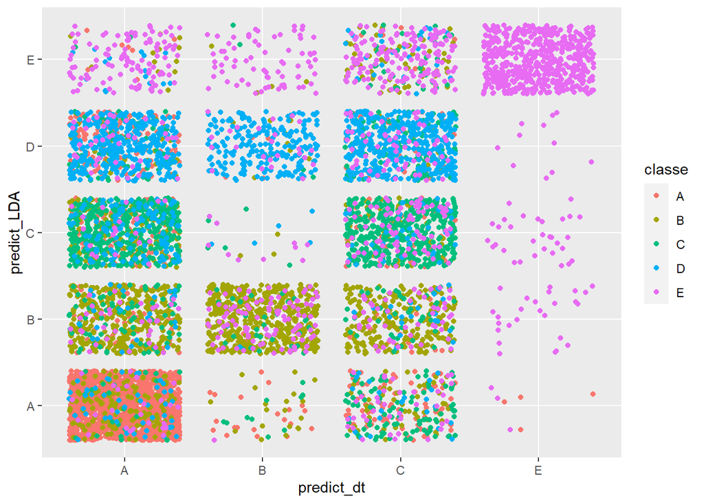

```r
qplot(predict_dt,predict_LDA,colour = classe, data = myTesting, geom = "jitter")
```

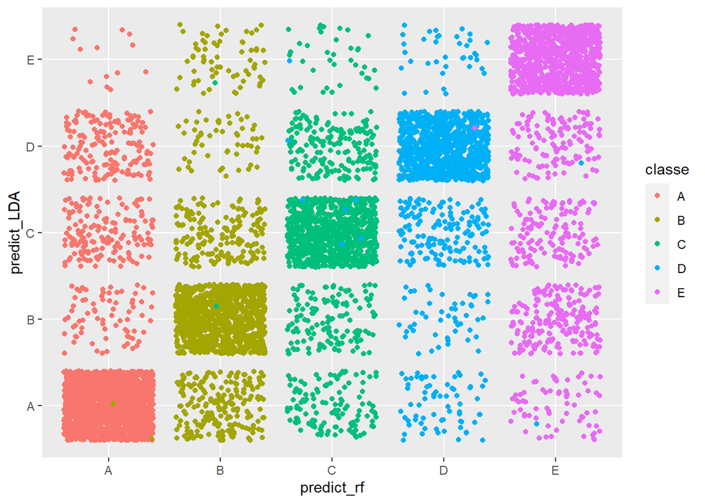

```r
qplot(predict_rf,predict_LDA,colour = classe, data = myTesting, geom = "jitter")
```

[output not shown]